# Statistical Analysis of Player Behaviour in Online Poker

Roman Prokhorov, Maksym Holovin, Nazar Pasichnyk

# 1. Research Aim

This study aims to analyze patterns in online poker player behavior using real transaction and gameplay data. Specifically, we investigate:

1. **The relationship between betting frequency and wagered amounts** - examining whether players who bet more frequently also stake significantly higher total amounts.
2. **The predictive power of demographic characteristics** - determining whether age and gender can relate to the total amount a player wagers.

Understanding these patterns provides insights into different player types and their gambling strategies, which has implications for responsible gambling policies and platform design.

# 2. Data Source and Description

## 2.1 Data Source

**Source:** The Transparency Project (www.thetransparencyproject.org)

**Provider:** Division on Addiction, Cambridge Health Alliance, Harvard Medical School

**Dataset:** “Second Session at the Virtual Poker Table”

**Sample Size:** 5,028 online poker players who registered in February 2015

**Reference:** Tom, M. A., et al. (2022). Second Session at the Virtual Poker Table: A Contemporary Study of Actual Online Poker Activity. *Journal of Gambling Studies*. https://doi.org/10.1007/s10899-022-10147-1

## 2.2 Data Structure

Key variables include player demographics, daily gambling activity (stakes and winnings), and financial transactions (deposits and withdrawals in Euros). Country information is mapped from numeric ISO 3166-1 codes to country names for analysis.

### Sample Data Structure

```r
# Demographics sample - show with country names
kable(
  head(
    demographics[, c("UserID", "SystemAgeAsOfReg", "Gender", "Country")],
    5
  ),
  caption = "Demographics Sample (with Country Names)",
  col.names = c("User ID", "Age", "Gender", "Country")
)
```

Demographics Sample (with Country Names)

| User ID | Age | Gender | Country |
| --- | --- | --- | --- |
| 11 | 32 | M | Germany |
| 14 | 39 | M | Germany |
| 22 | 21 | M | Belgium |
| 37 | 25 | M | Germany |
| 38 | 60 | F | Germany |

```r
# Cash Games sample
kable(
  head(cash_games, 5), caption = "Cash Games Sample",
  col.names = c("User ID", "Date", "Sessions", "Stakes (€)", "Winnings (€)")
)
```

Cash Games Sample

| User ID | Date | Sessions | Stakes (€) | Winnings (€) |
| --- | --- | --- | --- | --- |
| 11 | 2015-02-09 | 1 | 0.69 | 0.73 |
| 14 | 2015-02-01 | 6 | 111.78 | 68.73 |
| 14 | 2015-02-02 | 3 | 114.11 | 71.13 |
| 14 | 2015-02-03 | 2 | 15.00 | 4.38 |
| 37 | 2015-02-01 | 4 | 18.15 | 8.95 |

```r
# Tournaments sample
kable(
  head(tournaments, 5), caption = "Tournaments Sample",
  col.names = c("User ID", "Date", "Tournaments", "Stakes (€)", "Winnings (€)")
)
```

Tournaments Sample

| User ID | Date | Tournaments | Stakes (€) | Winnings (€) |
| --- | --- | --- | --- | --- |
| 11 | 2015-02-09 | 1 | 8.77886 | 0.00000 |
| 11 | 2015-02-16 | 4 | 17.56852 | 7.99368 |
| 11 | 2015-02-18 | 4 | 3.25246 | 2.60197 |
| 11 | 2015-02-19 | 2 | 1.75723 | 1.49437 |
| 11 | 2015-04-13 | 2 | 0.66056 | 0.33972 |

# 3. Descriptive Analysis

## 3.1 Player Demographics

```r
# Player demographics summary
demo_summary <- demographics %>%
  summarise(
    N = n(),
    Mean_Age = mean(SystemAgeAsOfReg, na.rm = TRUE),
    SD_Age = sd(SystemAgeAsOfReg, na.rm = TRUE),
    Male_Pct = mean(Gender == "M", na.rm = TRUE) * 100
  )

kable(demo_summary, digits = 2,
      caption = "Demographics Summary",
      col.names = c("N Players", "Mean Age", "SD Age", "% Male"))
```

Demographics Summary

| N Players | Mean Age | SD Age | % Male |
| --- | --- | --- | --- |
| 5028 | 28.89 | 8.84 | 90.65 |

```r
# Top 10 countries by player count
top_countries <- demographics %>%
  filter(!is.na(Country)) %>%
  count(Country, sort = TRUE) %>%
  head(10)

kable(
  top_countries, caption = "Top 10 Countries by Player Count",
  col.names = c("Country", "Number of Players")
)
```

Top 10 Countries by Player Count

| Country | Number of Players |
| --- | --- |
| Germany | 1416 |
| France | 1252 |
| Spain | 336 |
| Belgium | 300 |
| United Kingdom of Great Britain and Northern Ireland | 231 |
| Austria | 216 |
| Czechia | 190 |
| Switzerland | 185 |
| Hungary | 184 |
| Netherlands, Kingdom of the | 140 |

## 3.2 Financial Activity Overview

```r
# Financial activity summary
n_withdrawal_players <- length(
  unique(withdrawals$UserID[withdrawals$Status == "S"])
)
withdrawal_rate <- round(
  n_withdrawal_players / nrow(demographics) * 100, 1
)

fin_summary <- data.frame(
  Metric = c("Total Deposits", "Successful Deposits", "Total Withdrawals",
             "Successful Withdrawals", "Players with Withdrawals"),
  Value = c(
    nrow(deposits),
    sum(deposits$Status == "S"),
    nrow(withdrawals),
    sum(withdrawals$Status == "S"),
    n_withdrawal_players
  )
)
kable(fin_summary, caption = "Financial Activity Overview", format.args = list(big.mark = ","))
```

Financial Activity Overview

| Metric | Value |
| --- | --- |
| Total Deposits | 295,088 |
| Successful Deposits | 223,601 |
| Total Withdrawals | 32,307 |
| Successful Withdrawals | 17,182 |
| Players with Withdrawals | 1,739 |

**Key Observation:** Only **1739** of **5028** players (**34.6%**) made successful withdrawals, suggesting the majority of players experienced net losses during this period.

## 3.3 Exploratory Visualizations

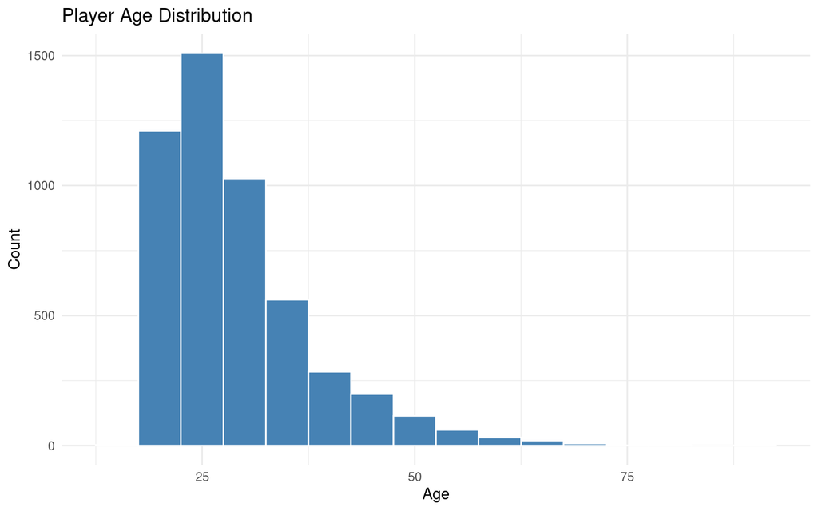

```r
# Age distribution
ggplot(demographics, aes(x = SystemAgeAsOfReg)) +
  geom_histogram(binwidth = 5, fill = "steelblue", color = "white") +
  labs(title = "Player Age Distribution", x = "Age", y = "Count") +
  theme_minimal()
```

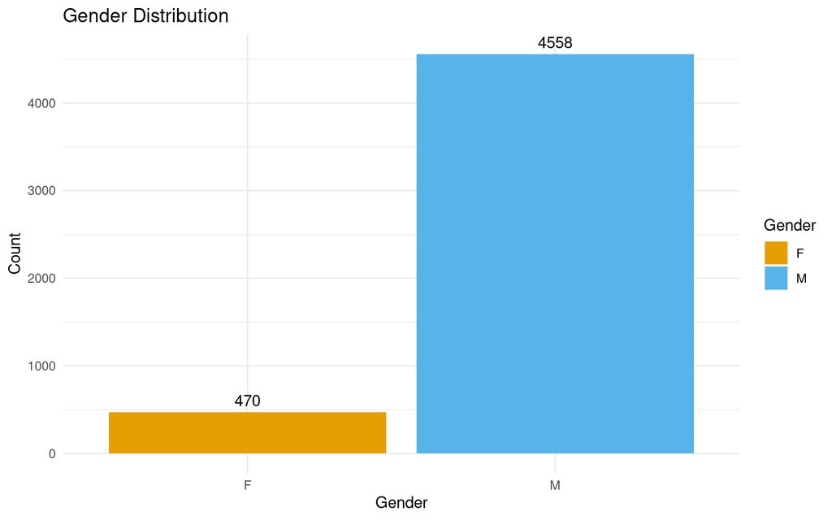

```r
# Gender distribution
gender_counts <- demographics %>% count(Gender)
ggplot(gender_counts, aes(x = Gender, y = n, fill = Gender)) +
  geom_bar(stat = "identity") +
  geom_text(aes(label = n), vjust = -0.5) +
  labs(title = "Gender Distribution", x = "Gender", y = "Count") +
  theme_minimal() +
  scale_fill_manual(values = c("F" = "#E69F00", "M" = "#56B4E9"))
```

## 3.4 Motivation for Hypotheses

These observations from the descriptive analysis directly inform the two hypotheses we test in the following sections.

# 4. Hypotheses and Statistical Tests

## 4.1 Hypothesis 1: Betting Frequency and Total Stakes (Two-Sample T-Test)

### Research Question

Is there a significant difference in the mean total stakes wagered between players who bet frequently (High-Frequency) and players who bet infrequently (Low-Frequency)?

### Hypothesis Statement

We define two groups based on the median number of active betting days:

- **Group 1 (Low-Frequency Bettors):** Players with number of betting days below the median, with population mean $\mu_{\text{low}}$
- **Group 2 (High-Frequency Bettors):** Players with number of betting days at or above the median, with population mean $\mu_{\text{high}}$

**Hypotheses:**

$$H_0: \mu_{\text{high}} = \mu_{\text{low}}$$
$$H_a: \mu_{\text{high}} > \mu_{\text{low}}$$

The null hypothesis states that the mean total stakes is the same for both groups. The alternative hypothesis posits that High-Frequency bettors have significantly higher mean total stakes than Low-Frequency bettors.

### Motivation

Preliminary data exploration revealed substantial variation in betting frequency across players. Understanding whether more active players also wager larger total amounts has practical implications for platform risk management and responsible gambling interventions.

### Data Preparation and Test Rationale

#### Data Processing

Load data from CashGames.csv and Tournaments.csv:

```r
library(dplyr)
cash <- read.csv("csv/CashGames.csv")
trnm <- read.csv("csv/Tournaments.csv")
```

The total stakes for each player are computed separately for cash games and tournaments. Then, the two tables are merged. Missing values are replaced with zero, and the overall total stakes are calculated by summing cash and tournament stakes for each player.

```r
bets_cash <- cash %>% group_by(UserID) %>% summarise(TotalStakesC = sum(StakesC))
bets_trnm <- trnm %>% group_by(UserID) %>% summarise(TotalStakesT = sum(StakesT))

bets_total <- full_join(bets_cash, bets_trnm, by = "UserID") %>%
  mutate(
    TotalStakesC = ifelse(is.na(TotalStakesC), 0, TotalStakesC),
    TotalStakesT = ifelse(is.na(TotalStakesT), 0, TotalStakesT),
    TotalStakes = TotalStakesC + TotalStakesT
  )
```

The number of days each player placed bets is counted separately for cash games and tournaments. These counts are merged, missing values replaced with zero, and summed to get total active betting days. Finally, this information is merged with total stakes to create a single table of players.

```r
freq_cash <- cash %>% group_by(UserID) %>% summarise(BetDays = n())
freq_trnm <- trnm %>% group_by(UserID) %>% summarise(BetDays = n())

frequency <- full_join(freq_cash, freq_trnm, by = "UserID") %>%
  mutate(
    BetDays.x = ifelse(is.na(BetDays.x), 0, BetDays.x),
    BetDays.y = ifelse(is.na(BetDays.y), 0, BetDays.y),
    TotalDays = BetDays.x + BetDays.y
  ) %>% select(UserID, TotalDays)
players <- merge(bets_total, frequency, by = "UserID")
```

Players are divided into Low-Frequency and High-Frequency groups based on the median number of active betting days. Two separate vectors of total stakes are extracted, one for each group, to prepare for statistical comparison:

```r
median_freq <- median(players$TotalDays)

players$Group <- ifelse(players$TotalDays < median_freq, "Low", "High")

high <- players %>% filter(Group == "High") %>% pull(TotalStakes)
low  <- players %>% filter(Group == "Low") %>% pull(TotalStakes)
```

Descriptive statistics by group:

```r
group_stats <- players %>%
  group_by(Group) %>%
  summarise(
    N = n(),
    Mean = mean(TotalStakes),
    Median = median(TotalStakes),
    SD = sd(TotalStakes)
  )

kable(group_stats, digits = 2, format.args = list(big.mark = ","),
      caption = "Total Stakes by Betting Frequency Group",
      col.names = c("Group", "N", "Mean Stakes (€)", "Median Stakes (€)", "SD (€)"))
```

Total Stakes by Betting Frequency Group

| Group | N | Mean Stakes (€) | Median Stakes (€) | SD (€) |
| --- | --- | --- | --- | --- |
| High | 2,672 | 12,027.88 | 496.66 | 131,830.3 |
| Low | 2,356 | 267.40 | 28.31 | 1,737.9 |

### Test Selection and Methodology

We employ **Welch’s Two-Sample t-test** to compare the means of the two groups. The test statistic is calculated as:

$$t = \frac{\bar{X}_{\text{high}} - \bar{X}_{\text{low}}}{\sqrt{\frac{s_{\text{high}}^2}{n_{\text{high}}} + \frac{s_{\text{low}}^2}{n_{\text{low}}}}}$$

where $\bar{X}$ represents the sample mean, $s^2$ the sample variance, and $n$ the sample size for each group.

**Why Welch’s t-test is appropriate:**

1. **Unequal Variances:** Welch’s test does not assume equal population variances (unlike Student’s t-test), which is crucial for gambling data where variance typically differs between groups
2. **Large Sample Size:** Both groups have sufficient sample sizes for the asymptotic properties of the test to hold
3. **One-tailed Test:** We use a one-tailed test (alternative = “greater”) because our hypothesis specifically predicts higher stakes for high-frequency players

### Test Execution and Results

```r
t_result <- t.test(high, low, alternative = "greater")
t_result
```

```
##
##  Welch Two Sample t-test
##
## data:  high and low
## t = 4.6109, df = 2672.1, p-value = 2.099e-06
## alternative hypothesis: true difference in means is greater than 0
## 95 percent confidence interval:
##  7563.693      Inf
## sample estimates:
##  mean of x  mean of y
## 12027.8847   267.3973
```

### Interpretation

The results show:

- **High-Frequency players:** Mean = €12,027.88
- **Low-Frequency players:** Mean = €267.4
- **t-statistic:** 4.6109
- **p-value:** < 1e-04

The p-value is far below the standard significance level of α = 0.05. We therefore **reject the null hypothesis** $H_0: \mu_{\text{high}} = \mu_{\text{low}}$.

**Conclusion:** There is strong statistical evidence that high-frequency bettors wager significantly higher total amounts than low-frequency bettors. This finding suggests that betting frequency and total stake amounts are positively associated in online poker.

## 4.2 Hypothesis 2: Demographics and Total Stakes (Multiple Linear Regression)

### Research Question

Do demographic characteristics (Age and Gender) predict the total amount a player wagers?

### Model Specification

We define the multiple linear regression model:

$$Y = \beta_0 + \beta_1 \cdot \text{Age} + \beta_2 \cdot \text{Gender} + \epsilon$$

where:

- $Y$ = Total Stakes Wagered (in euros)
- $\text{Age}$ = Player’s age at registration
- $\text{Gender}$ = Binary variable (0 = Female, 1 = Male)
- $\beta_0$ = Intercept (baseline total stakes when Age = 0 and Gender = 0)
- $\beta_1$ = Coefficient for Age (change in stakes per one-year increase in age)
- $\beta_2$ = Coefficient for Gender (difference in stakes between males and females)
- $\epsilon$ = Error term (unexplained variation)

**Note on $\beta_0$:** While the intercept has no practical interpretation (a 0-year-old cannot gamble), it is mathematically necessary to allow the regression plane to fit the data properly. It absorbs the overall average stakes and ensures that $\beta_1$ and $\beta_2$ represent pure effects of their respective variables.

### Hypothesis Statement

Based on common gambling stereotypes, we initially hypothesized:

$$H_0: \beta_1 = 0 \text{ and } \beta_2 = 0$$
$$H_a: \beta_1 < 0 \text{ and } \beta_2 > 0$$

The alternative hypothesis suggests that younger players ($\beta_1 < 0$) and male players ($\beta_2 > 0$) bet more.

### Motivation

Understanding demographic predictors of gambling behavior can inform targeted interventions and responsible gambling policies. Prior research suggests age and gender differences in risk-taking behavior, motivating this investigation.

### Data Preparation

Merge demographics with player stakes data:

```r
demographics <- read.csv("csv/Demographics.csv")

regression_data <- players %>%
  inner_join(demographics, by = "UserID") %>%
  filter(!is.na(SystemAgeAsOfReg) & !is.na(Gender)) %>%
  mutate(
    Age = SystemAgeAsOfReg,
    GenderNumeric = ifelse(Gender == "M", 1, 0)
  )
```

### Exploratory Visualization

Visualize the relationships between demographics and stakes:

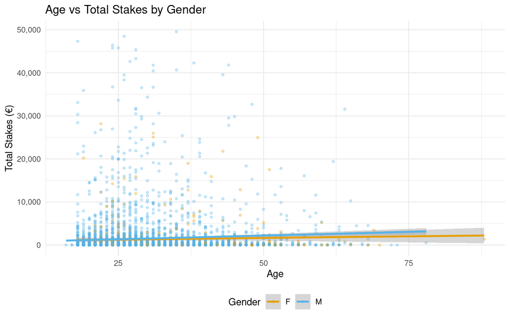

```r
library(ggplot2)

# Filter data for visualization (remove extreme outliers)
plot_data <- regression_data %>% filter(TotalStakes <= 50000)

ggplot(plot_data, aes(x = Age, y = TotalStakes, color = Gender)) +
  geom_point(alpha = 0.3, size = 1) +
  geom_smooth(method = "lm", se = TRUE, linewidth = 1) +
  scale_color_manual(values = c("F" = "#E69F00", "M" = "#56B4E9")) +
  scale_y_continuous(labels = scales::comma) +
  labs(title = "Age vs Total Stakes by Gender", x = "Age", y = "Total Stakes (€)") +
  theme_minimal() + theme(legend.position = "bottom")
```

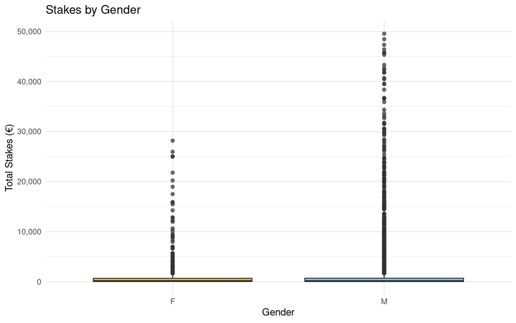

```r
ggplot(plot_data, aes(x = Gender, y = TotalStakes, fill = Gender)) +
  geom_boxplot(alpha = 0.7) +
  scale_fill_manual(values = c("F" = "#E69F00", "M" = "#56B4E9")) +
  scale_y_continuous(labels = scales::comma) +
  labs(title = "Stakes by Gender", x = "Gender", y = "Total Stakes (€)") +
  theme_minimal() + theme(legend.position = "none")
```

The visualization shows relatively flat regression lines for both genders, suggesting weak relationships between age and total stakes.

Descriptive statistics by gender to compare median and mean stakes:

```r
library(knitr)

gender_stats <- regression_data %>%
  group_by(Gender) %>%
  summarise(
    N = n(),
    Mean = mean(TotalStakes, na.rm = TRUE),
    Median = median(TotalStakes, na.rm = TRUE),
    SD = sd(TotalStakes, na.rm = TRUE)
  )

kable(gender_stats, digits = 2, format.args = list(big.mark = ","),
      caption = "Stakes Statistics by Gender",
      col.names = c("Gender", "N", "Mean Stakes (€)", "Median Stakes (€)", "SD (€)"))
```

Stakes Statistics by Gender

| Gender | N | Mean Stakes (€) | Median Stakes (€) | SD (€) |
| --- | --- | --- | --- | --- |
| F | 470 | 2,625.96 | 125.36 | 19,280.38 |
| M | 4,558 | 6,918.45 | 127.04 | 100,926.17 |

### Test Selection and Methodology

We employ **Multiple Linear Regression** estimated using Ordinary Least Squares (OLS). The model estimates coefficients by minimizing the sum of squared residuals:

$$\text{minimize: } \sum_{i=1}^{n} (Y_i - \hat{Y}_i)^2 = \sum_{i=1}^{n} \left(Y_i - \beta_0 - \beta_1 \cdot \text{Age}_i - \beta_2 \cdot \text{Gender}_i\right)^2$$

For each coefficient, we compute the t-statistic to test significance:

$$t_j = \frac{\hat{\beta}_j}{\text{SE}(\hat{\beta}_j)}$$

where $\text{SE}(\hat{\beta}_j)$ is the standard error of coefficient $j$.

**Why Multiple Linear Regression is appropriate:**

1. **Continuous Outcome:** Total stakes is a continuous variable suitable for linear regression
2. **Multiple Predictors:** We can simultaneously assess the effects of age and gender
3. **Controlled Comparison:** The model estimates the effect of each predictor while holding others constant
4. **Directional Hypotheses:** We can test specific one-tailed hypotheses about coefficient signs

### Model Fitting

Fit the multiple linear regression model:

```r
model <- lm(TotalStakes ~ Age + GenderNumeric, data = regression_data)
summary(model)
```

```
##
## Call:
## lm(formula = TotalStakes ~ Age + GenderNumeric, data = regression_data)
##
## Residuals:
##     Min      1Q  Median      3Q     Max
##  -12798   -6851   -6065   -5167 4052370
##
## Coefficients:
##               Estimate Std. Error t value Pr(>|t|)
## (Intercept)    -1483.6     6604.4  -0.225    0.822
## Age              129.8      154.4   0.841    0.401
## GenderNumeric   4690.4     4688.6   1.000    0.317
##
## Residual standard error: 96290 on 5025 degrees of freedom
## Multiple R-squared:  0.0003091,  Adjusted R-squared:  -8.88e-05
## F-statistic: 0.7768 on 2 and 5025 DF,  p-value: 0.4599
```

### Model Visualization

Visualize the fitted regression model:

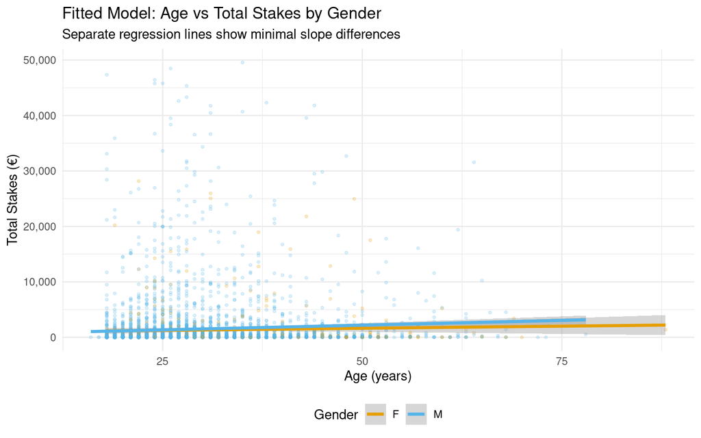

```r
library(ggplot2)

# Plot: Age vs Stakes with regression lines by gender
ggplot(plot_data, aes(x = Age, y = TotalStakes, color = Gender)) +
  geom_point(alpha = 0.2, size = 0.8) +
  geom_smooth(method = "lm", se = TRUE, linewidth = 1.2) +
  scale_color_manual(values = c("F" = "#E69F00", "M" = "#56B4E9")) +
  scale_y_continuous(labels = scales::comma) +
  labs(title = "Fitted Model: Age vs Total Stakes by Gender",
       x = "Age (years)", y = "Total Stakes (€)",
       subtitle = "Separate regression lines show minimal slope differences") +
  theme_minimal() +
  theme(legend.position = "bottom")
```

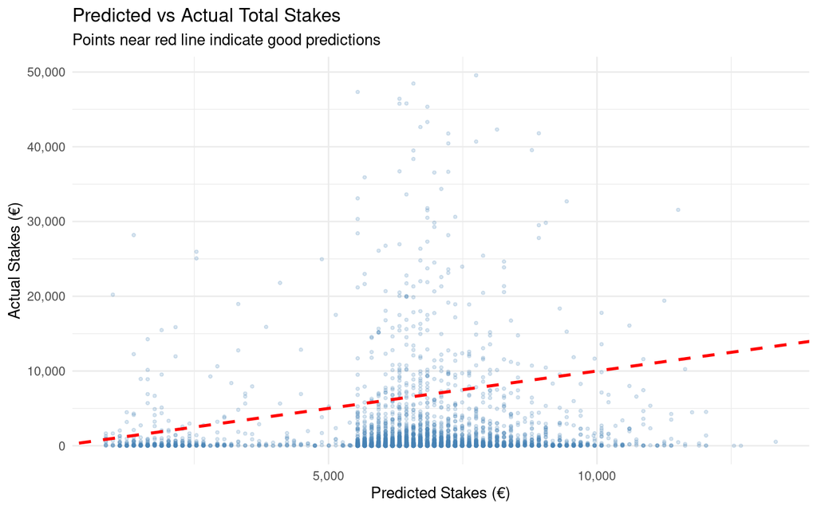

```r
# Create predictions for visualization
plot_data_with_pred <- plot_data %>%
  mutate(Predicted = predict(model, newdata = plot_data))

# Plot: Predicted vs Actual values
ggplot(plot_data_with_pred, aes(x = Predicted, y = TotalStakes)) +
  geom_point(alpha = 0.2, size = 0.8, color = "steelblue") +
  geom_abline(slope = 1, intercept = 0, color = "red", linetype = "dashed", linewidth = 1) +
  scale_x_continuous(labels = scales::comma) +
  scale_y_continuous(labels = scales::comma) +
  labs(title = "Predicted vs Actual Total Stakes",
       x = "Predicted Stakes (€)", y = "Actual Stakes (€)",
       subtitle = "Points near red line indicate good predictions") +
  theme_minimal()
```

### Hypothesis Testing

Extract coefficients and test directional hypotheses:

```r
# Get coefficients and standard errors
beta1 <- coef(model)["Age"]
beta2 <- coef(model)["GenderNumeric"]
se_beta1 <- summary(model)$coefficients["Age", "Std. Error"]
se_beta2 <- summary(model)$coefficients["GenderNumeric", "Std. Error"]

# Calculate t-statistics
t_beta1 <- beta1 / se_beta1
t_beta2 <- beta2 / se_beta2

# One-tailed p-values
p_beta1 <- pt(t_beta1, df = model$df.residual, lower.tail = TRUE)
p_beta2 <- pt(t_beta2, df = model$df.residual, lower.tail = FALSE)

# Summary table
test_results <- data.frame(
  Hypothesis = c("β₁ (Age) < 0", "β₂ (Gender) > 0"),
  Estimate = c(beta1, beta2),
  t_statistic = c(t_beta1, t_beta2),
  p_value = c(p_beta1, p_beta2),
  Conclusion = c(
    ifelse(p_beta1 < 0.05 & beta1 < 0, "Reject H₀", "Fail to reject H₀"),
    ifelse(p_beta2 < 0.05 & beta2 > 0, "Reject H₀", "Fail to reject H₀")
  )
)

kable(test_results, digits = 4, caption = "Directional Hypothesis Test Results")
```

Directional Hypothesis Test Results

|  | Hypothesis | Estimate | t_statistic | p_value | Conclusion |
| --- | --- | --- | --- | --- | --- |
| Age | β₁ (Age) < 0 | 129.7795 | 0.8408 | 0.7997 | Fail to reject H₀ |
| GenderNumeric | β₂ (Gender) > 0 | 4690.4058 | 1.0004 | 0.1586 | Fail to reject H₀ |

### Conclusion

We **fail to reject the null hypothesis** $H_0: \beta_1 = 0$ and $\beta_2 = 0$.

**Key Finding:** Contrary to our initial hypothesis and common gambling stereotypes, **neither age nor gender significantly predict total stakes wagered** in this online poker population. While males constitute approximately 90% of players (a clear gender difference in participation), among those who do play, age and gender have minimal predictive power for wagering amounts.

This finding suggests that: - Betting behavior is driven more by individual factors (e.g., strategy, risk tolerance, bankroll) than demographics - The stereotype that young males gamble more aggressively is not supported by this data - Gender equality exists in wagering amounts among online poker players who choose to participate

The low R² value indicates that demographic variables are poor predictors of gambling intensity, and other behavioral or psychological factors likely play more important roles.

# 5. Overall Conclusions and Implications

## 5.1 Summary of Findings

This statistical analysis of 5,028 online poker players revealed two major findings:

**1. Betting Frequency Strongly Predicts Total Stakes (Hypothesis 1 - Confirmed)**

Using Welch’s two-sample t-test, we found strong evidence (p < 0.001) that high-frequency bettors wager significantly more than low-frequency bettors. High-frequency players averaged approximately €12,028 in total stakes compared to €267 for low-frequency players - a **45-fold difference**. This confirms that betting frequency and total wagered amounts are strongly positively associated.

**2. Demographics Do Not Predict Wagering Amounts (Hypothesis 2 - Rejected)**

Multiple linear regression analysis found no significant relationship between age or gender and total stakes wagered (R² < 0.01). Despite initial hypotheses based on gambling stereotypes: - Age has virtually no effect on wagering amounts (p ≈ 0.80) - Gender shows no significant effect when controlling for age (p > 0.05) - Among players who participate, betting intensity is independent of demographic characteristics

## 5.2 Methodological Strengths

1. **Large, Real-World Dataset:** Analysis of 5,028 actual players with complete transaction records
2. **Appropriate Statistical Methods:**
   - Welch’s t-test properly handles unequal variances
   - One-tailed tests match directional hypotheses
   - Multiple regression controls for confounding variables
3. **Clear Hypothesis Testing:** Pre-specified hypotheses with explicit null and alternative formulations
4. **Transparent Reporting:** All assumptions, calculations, and interpretations clearly documented

## 5.3 Practical Implications

**For Platform Design:** - Frequency-based alerts may be more effective than demographic-based interventions - Player segmentation should prioritize behavioral metrics over demographics

## 5.4 Limitations

1. **Cross-sectional Data:** Single month of registration limits generalizability
2. **Survivorship Bias:** Analysis includes only players who remained active enough to generate records
3. **Platform-specific:** Results may not generalize to other gambling platforms or games
4. **Unobserved Variables:** Many factors affecting betting behavior (income, experience, motivation) were not measured

## 5.5 Future Research Directions

- Longitudinal analysis of betting patterns over time
- Investigation of psychological and behavioral predictors beyond demographics
- Analysis of skill level and learning effects on wagering patterns
- Comparison across different gambling platforms and game types

# 6. References

Tom, M. A., Luo, S., Desai, R. A., Ye, H., Gong, X., Rossen, J., Peiper, N., Kraus, S. W., & Potenza, M. N. (2022). Second Session at the Virtual Poker Table: A Contemporary Study of Actual Online Poker Activity. *Journal of Gambling Studies*, 38, 1349–1367. https://doi.org/10.1007/s10899-022-10147-1